# 10102018 kinetic spec assay

### purpose

establish temperature denaturation curve with unprotected A.P. gathering controls.

### setup

- no osmolyte
- no freezing
- initial [A.P]: 50 mg/mL in A.P storage solution
- [A.P] during incubation: *2.5 mg/mL* in A.P assay buffer
- incubation temp: 60, 65, 70 deg C
- time pts: 0,15,30,90 min
- A.P storage condition: temp,time
- 3 temps x 4 time pts= **12** different conditions
- 1 tube per condition
- 3 reps per condition
- *total: 12 tubes=12 conditions, 36 reps*
- Final [A.P] in cuvette (assay concentration): 0.125 mg/mL in assay

| reagent | final concentration |
| --- | --- |
| 50 mM A.P @ -80 deg C | 2.5 mg/mL in A.P assay buffer |
| PNPP | 50 mg/mL in H2O |

#### individual microfuge tube contents

- 131.25 uL 2.5 mg/mL A.P dilution in A.P assay buffer per tube=3.5 replicates per tube

### master mix for 2.5 mg/mL A.P in A.P assay buffer

- C1=50mg/mL
- *V1=85.3125 uL 50 mg/mL A.P*
- C2=2.5 mg/mL A.P in A.P assay buffer
- V2=131.25uL x 13 tubes=1.70625 mL
- A.P assay buffer to add=V2-V1=1706.25 uL - 85.3125 uL = *1620.9375 uL*

### PNPP 50 mg/mL calculations

- vol needed=7.5 uL x 36 reps = 270 uL --> *300 uL H2O*
- 50 mg/mL x .3 mL = *15 mg PNPP*

#### cuvette contents (assay)

| Reagent | Volume | Final Concentration (in assay) | blank? |
| --- | --- | --- | --- |
| Alkaline phosphatase assay buffer | 705 uL |  | yes |
| 50 mg/mL PNPP | 7.5 uL |  | yes |
| 2.5 mg/mL Alkaline phosphatase dilution in A.P assay buffer | 37.5 uL | 0.125 mg/mL | no |

### Procedure

- see "kinetic_spec_assay" for more info about kinetic spec assay procedures

*A.P treatment:* *thaw on ice, store on ice*

- initial [A.P]: 50 mg/mL in A.P storage solution
- dilute 50 mg/mL A.P in storage solution to 2.5 mg/mL A.P in A.P assay buffer master mix
- make 131.25 x 13 uL of A.P master mix
- aliquot 131.25 A.P master mix in each tube
- incubate at specified temp for 0,15,30,90 mins
- after incubation period for each tube, let A.P tube sit on ice for 5 mins

*data collection*

- blank spec with A.P assay buffer and 50 mg/mL PNPP
- start data collection w/blank
- add 37.5 uL 2.5 mg/mL A.P dilution into cuvette
- continue with data collection until equilibrium reached
- record dAbs410nm/sec and dAbs410nm/min for each run

*data analysis*

### A.P activity over time

```
[0.0, 0.0, 0.0, 15.0, 30.0, 30.0, 30.0, 90.0] [nan, nan, nan, 0.019465, nan, nan, nan, 0.01743] [nan, nan, nan, 0.0005849999999999987, nan, nan, nan, 0.0]
[0.0, 0.0, 0.0, 15.0, 30.0, 90.0] [nan, nan, nan, 0.016055, 0.013215000000000001, 0.006627333333333333] [nan, nan, nan, 0.0006050000000000005, 0.00015499999999999976, 0.0002891658501429393]
[0.0, 15.0, 30.0, 90.0] [0.035333333333333335, 0.029920000000000002, 0.021476666666666668, 0.005521000000000001] [0.0007327725128275182, 0.001042337117571214, 0.0012591355059016571, 8.63288287113096e-05]
```

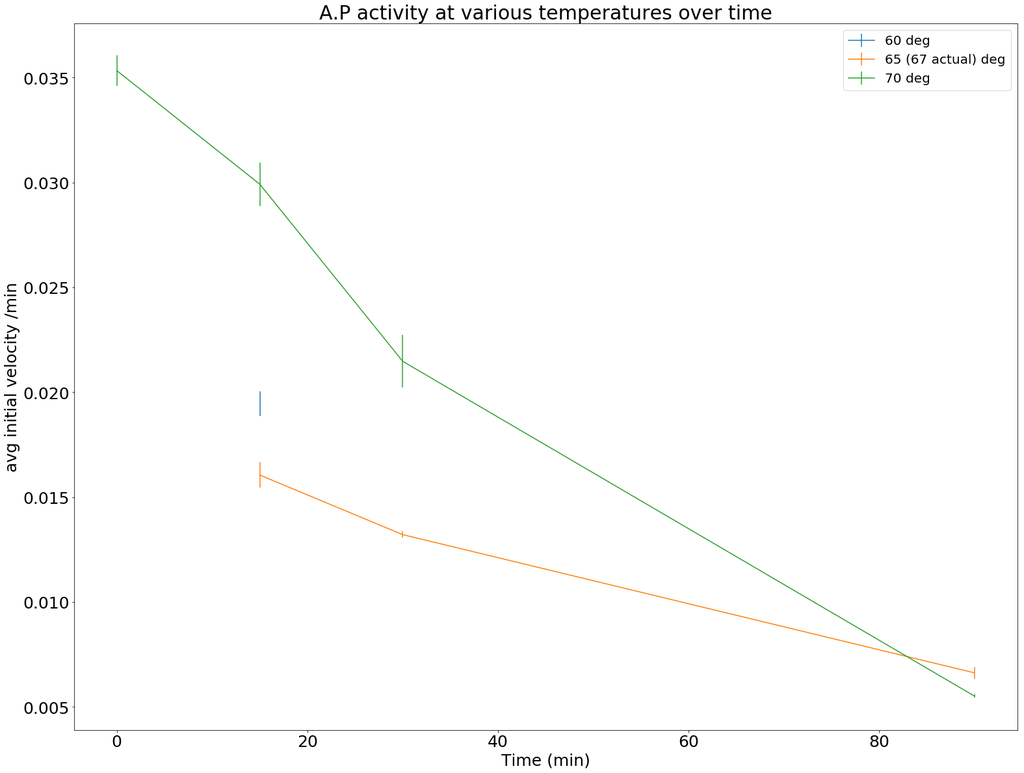

```python
import csv
import sys
import gc
sys.path.insert(0, 'process_csv/')
from process_csv import *
from scipy.stats import linregress
import numpy as np
import matplotlib.pyplot as plt
import requests
import pandas as pd
import random
import string
def Remove(duplicate):#remove duplicates from list
    final_list = []
    for num in duplicate:
        if num not in final_list:
            final_list.append(num)
    return final_list
with open("dataset/ap_10102018_init_vel.csv") as file:
    reader=csv.reader(file)
    data=list(reader)
header=data[0]
i=0
j=1
csvdict={}#csvdict module
while i<len(data[j]):
    csvdict[header[i]]=[]
    while j<len(data):
        csvdict[header[i]].append(data[j][i])
        j+=1
    j=1
    i+=1
for key,val in csvdict.items():
    val=list(map(float, [a for a in val if a]))
    csvdict[key]=val
csv_rowdict=defaultdict(list)#generate dict with first column as key, rest as values
time_head=csvdict['Time (min)']#timepoints
temp_head=header[1:4]#temp header
a=0
b=0
while a<len(time_head):
    while b<len(data[a][1:4]):
        csv_rowdict[time_head[a]].append(data[a+1][1:4][b])
        #print(data[a][1:4][b])
        b+=1
    b=0
    a+=1
for key,val in csv_rowdict.items():#convert all val in dict to float
    val=list(map(float, [a for a in val if a]))
    csv_rowdict[key]=val
val=list(map(float, [item for sublist in list(csv_rowdict.values()) for item in sublist]))#list of all initial velocity float in dict
ptval_dict=defaultdict(list)
for i in val:#generate dict with each initial velocity as key and corresponding [temp,time] as value. "val" is unique
    temp=[key for key, value in csvdict.items() if i in value].pop()
    time=[key for key, value in csv_rowdict.items() if i in value].pop()
    ptval_dict[i].append(temp)
    ptval_dict[i].append(time)
xval=[]
tempval=[]
meanval=[]
stdev=[]
for i in time_head:#group initial vel with same corresponding time,temp
    for j in temp_head:
        pts=[key for key, value in ptval_dict.items() if i in value and j in value]
        xval.append(i)#generate list of x values (time)
        tempval.append(j)#list of temperatures corresponding to time
        meanval.append(np.mean(pts))#list of mean of initial vel in each time,temp group
        stdev.append(np.std(pts))#list of stdev of initial vel in each time,temp group
to_plot=list(zip(xval,meanval,stdev,tempval))#zipped list of items to plot
to_plot=Remove(to_plot)#remove duplicates due to iteration
lentp=0#iterate thru to_plot=length of to_plot
tempheadlen=0#iterate thru list of temps=length of list of temp==3
plot_holderx=[]#list of xval to plot
plot_holdermean=[]#list of avg init vel to plot
plot_holderstdev=[]#list of stdev to plot
while tempheadlen<len(temp_head):
    plot_holderx=[]
    plot_holdermean=[]
    plot_holderstdev=[]
    lentp=0
    while lentp<len(to_plot):
        if to_plot[lentp][3]==temp_head[tempheadlen]:#pull all vals from to_plot with same temp
            plot_holderx.append(to_plot[lentp][0])#pull x values from to_plot zipped list
            plot_holdermean.append(to_plot[lentp][1])#pull avg values from to_plot zipped list
            plot_holderstdev.append(to_plot[lentp][2])#pull stdev values from to_plot zipped list
            lentp+=1
        else:#if "temp" at current to_plot index not equal to desired temp
            #print(False,temp_head[tempheadlen])
            lentp+=1
    plt.errorbar(plot_holderx,plot_holdermean,plot_holderstdev, label=temp_head[tempheadlen])
    print(plot_holderx,plot_holdermean,plot_holderstdev)
    tempheadlen+=1#move onto next temp
plt.xlabel("Time (min)")
plt.ylabel("avg initial velocity /min")
plt.title("A.P activity at various temperatures over time")
plt.rcParams["figure.figsize"] = [26,20]
plt.rcParams.update({'font.size': 25})
plt.legend(prop={'size': 20})
```